# Nonlinear Models (ISL 7)

## 3 Piecewise polynomials (regression splines)

- Instead of a single polynomial in $X$ over its whole domain, we can rather use different polynomials in regions defined by **knots**. E.g., a piecewise cubic polynomial with a single knot at $c$ takes the form
  $$y_i = \begin{cases}
  \beta_{01} + \beta_{11} x_i + \beta_{21} x_i^2 + \beta_{31} x_i^3 + \epsilon_i & \text{if } x_i < c \\
  \beta_{02} + \beta_{12} x_i + \beta_{22} x_i^2 + \beta_{32} x_i^3 + \epsilon_i & \text{if } x_i \ge c
  \end{cases}.$$
- Better to add constraints to the polynomials, e.g., continuity.
- Splines have the “maximum” amount of continuity.

[figure not shown]

### 3.1 Linear spline

- A **linear spline** with knots at $\xi_k$, $k = 1,\ldots,K$, is a piecewise linear polynomial continuous at each knot.
- We can represent this model as
  $$y_i = \beta_0 + \beta_1 b_1(x_i) + \beta_2 b_2(x_i) + \cdots + \beta_{K+1} b_{K+1}(x_i) + \epsilon_i,$$
  where $b_k$ are **basis functions**:
  $$\begin{eqnarray*}
  b_1(x_i) &=& x_i \\
  b_{k+1}(x_i) &=& (x_i - \xi_k)_+, \quad k=1,\ldots,K.
  \end{eqnarray*}$$
  Here $(\cdot)_+$ means positive part
  $$(x_i - \xi_i)_+ = \begin{cases}
  x_i - \xi_k & \text{if } x_i > \xi_k \\
  0 & \text{otherwise}
  \end{cases}.$$

### 3.2 Cubic splines

- A **cubic spline** with knots at $\xi_k$, $k = 1,\ldots,K$, is a piecewise cubic polynomial with continuous derivatives up to order 2 at each knot.
- Again we can represent this model with **truncated power basis functions**
  $$y_i = \beta_0 + \beta_1 b_1(x_i) + \beta_2 b_2(x_i) + \cdots + \beta_{K+3} b_{K+3}(x_i) + \epsilon_i,$$
  with
  $$\begin{eqnarray*}
  b_1(x_i) &=& x_i \\
  b_2(x_i) &=& x_i^2 \\
  b_3(x_i) &=& x_i^3 \\
  b_{k+3}(x_i) &=& (x_i - \xi_k)_+^3, \quad k = 1,\ldots,K,
  \end{eqnarray*}$$
  where
  $$(x_i - \xi_i)_+^3 = \begin{cases}
  (x_i - \xi_k)^3 & \text{if } x_i > \xi_k \\
  0 & \text{otherwise}
  \end{cases}.$$
- A cubic spline with $K$ knots costs $K+4$ parameters or degrees of freedom. That is $4(K+1)$ polynomial coefficients minus $3K$ constraints.
- While the truncated power basis is conceptually simple, it is not too attractive numerically: powers of large numbers can lead to severe rounding problems. In practice, **B-spline basis functions** are preferred for their computational efficiency. See ESL Chapter 5 Appendix.

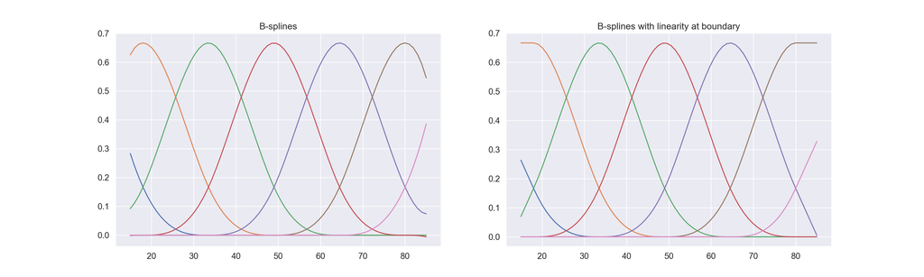

```python
from sklearn.preprocessing import SplineTransformer

# Cubic spline for age
X_age = np.array(X['age']).reshape(3000, 1)
x_plot = np.linspace(start = 15, stop = 85, num = 70)
X_plot = x_plot[:, np.newaxis]
bs_plot = SplineTransformer(
    degree = 3,
    # knots = np.array([25, 40, 60]).reshape(3, 1),
    n_knots = 5,
    extrapolation = 'continue',
    # include_bias = False
    ).fit(X_age).transform(X_plot)

ns_plot = SplineTransformer(
    degree = 3,
    # knots = np.array([25, 40, 60]).reshape(3, 1),
    n_knots = 5,
    extrapolation = 'linear',
    # include_bias = False
    ).fit(X_age).transform(X_plot)

# Plot
fig, axes = plt.subplots(ncols = 2, figsize = (20, 6))
axes[0].plot(x_plot, bs_plot)
# axes[0].legend(axes[0].lines, [f"spline {n}" for n in range(4)])
axes[0].set_title("B-splines")

axes[1].plot(x_plot, ns_plot)
# axes[1].legend(axes[0].lines, [f"spline {n}" for n in range(8)])
axes[1].set_title("B-splines with linearity at boundary")
plt.show()
```

### 3.3 Natural cubic splines

- Splines can have high variance at the outer range of the predictors.
- A **natural cubic spline** extrapolates linearly beyond the boundary knots. This adds $4 = 2 \times 2$ extra constraints, and allows us to put more internal knots for the same degrees of freedom as a regular cubic spline.
- A natural spline with $K$ knots has $K$ degrees of freedom.

**R**

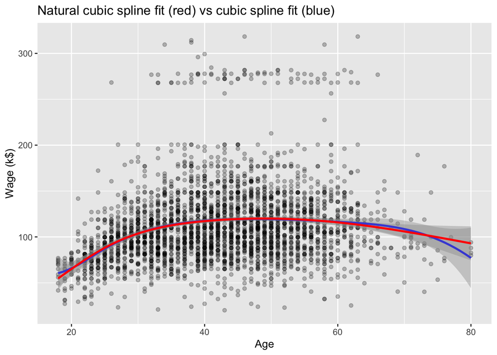

```r
library(splines)

# Plot wage ~ age
Wage %>%
  ggplot(mapping = aes(x = age, y = wage)) +
  geom_point(alpha = 0.25) +
  # Cubic spline
  geom_smooth(
    method = "lm",
    formula = y ~ bs(x, knots = c(25, 40, 60)),
    color = "blue"
    ) +
  # Natural cubic spline
  geom_smooth(
    method = "lm",
    formula = y ~ ns(x, knots = c(25, 40, 60)),
    color = "red"
    ) +
  labs(
    title = "Natural cubic spline fit (red) vs cubic spline fit (blue)",
    x = "Age",
    y = "Wage (k$)"
    )
```

### 3.4 Knot placement

- One strategy is to decide $K$, the number of knots, and then place them at appropriate quantiles of the observed $X$.
- In practice users often specify the degree of freedom and let software choose the number of knots and locations.

## 4 Smoothing splines

- Consider this criterion for fitting a smooth function $g(x)$ to some data:
  $$\text{minimize} \quad \sum_{i=1}^n (y_i - g(x_i))^2 + \lambda \int g''(t)^2 \, dt.$$
  - The first term is RSS, and tries to make $g(x)$ match the data at each $x_i$.
  - The second term is a **roughness penalty** and controls how wiggly $g(x)$ is. It is modulated by the tuning parameters $\lambda \ge 0$.
    - The smaller $\lambda$, the more wiggly the function, eventually interpolating $y_i$ when $\lambda = 0$.
    - As $\lambda \to \infty$, the function $g(x)$ becomes linear.
- It can be shown that this problem has an explicit, finite-dimensional, unique minimizer which is a natural cubic spline with knots at the unique values of the $x_i$.
- The roughness penalty controls the roughness via $\lambda$.
- Smoothing splines avoid the knot-selection issue, leaving a single $\lambda$ to be chosen.
- The vector of $n$ fitted values can be written as $\hat{g}_\lambda = S_\lambda y$, where $S_{\lambda}$ is an $n \times n$ matrix (determined by the $x_i$ and $\lambda$).
- The **effective degrees of freedom** are given by
  $$\text{df}_{\lambda} = \sum_{i=1}^n S_{\lambda,ii}.$$
  Thus we can specify `df` rather than $\lambda$.
- The leave-one-out (LOO) cross-validated error is given by
  $$\text{RSS}_{\text{CV}}(\lambda) = \sum_{i=1}^n \left[ \frac{y_i - \hat{g}_\lambda(x_i)}{1 - S_{\lambda,ii}} \right]^2.$$

**R**

`ggformula` package supplies `geom_spline` function for displaying smoothing spline fits.

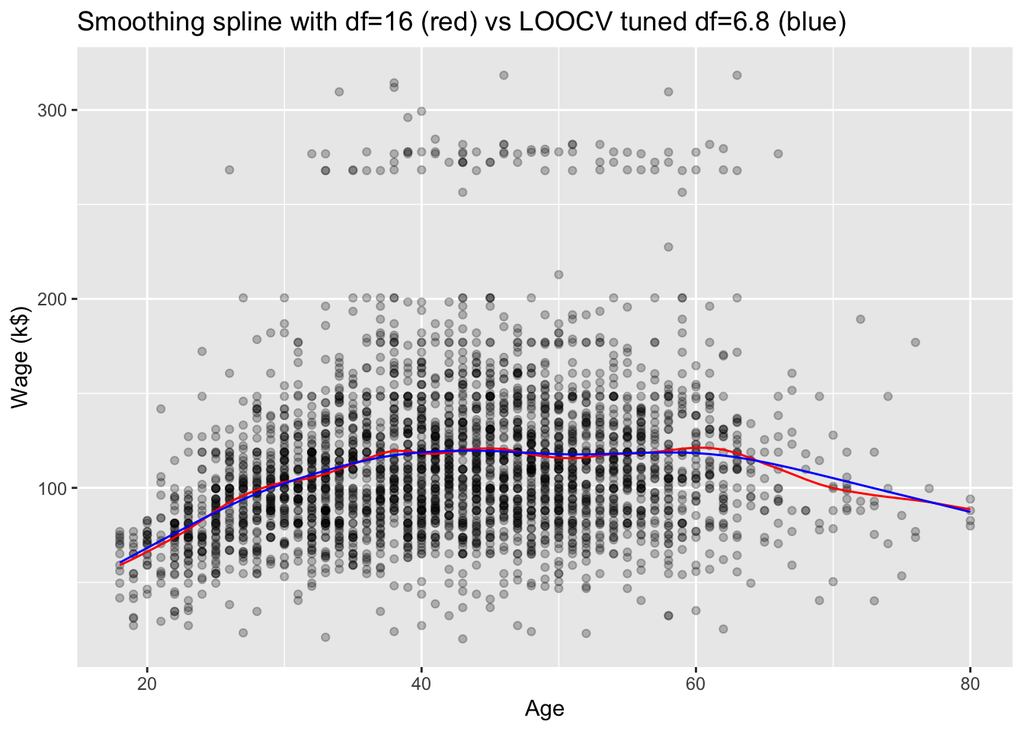

```r
library(ggformula)
library(splines)

# Plot wage ~ age
Wage %>%
  ggplot(mapping = aes(x = age, y = wage)) +
  geom_point(alpha = 0.25) +
  # Smoothing spline with df = 16
  geom_spline(
      df = 16,
      color = "red"
    ) +
  # Smoothing spline with GCV tuned df
  geom_spline(
    # df = 6.8,
    cv = TRUE,
    color = "blue"
    ) +
  labs(
    title = "Smoothing spline with df=16 (red) vs LOOCV tuned df=6.8 (blue)",
    x = "Age",
    y = "Wage (k$)"
    )
```

- Application to logistic regression
  $$\log\frac{\mathbf{P}(Y=1|X)}{\mathbf{P}(Y=0|X)} = f(X),$$
  therefore
  $$\mathbf{P}(Y=1|X) = \frac{\exp(f(X))}{1 + \exp(f(X))} = p(x).$$
- The penalized The log-likelihood criterion
  $$\ell(f,\lambda) = \sum_{i=1}^n \left[ y_i \log p(x_i) + (1-y_i) \log (1-p(x_i)) \right] - \lambda \int f''(t)^2 \, dt.$$
- The solution is a natural cubic spline with knots at the unique values of the $x_i$.

## 5 Local regression

[figure not shown]

- With a sliding weight function, we fit separate linear fits over the range of $X$ by weighted least squares.
- At $X=x_0$,
  $$\text{minimize} \quad \sum_{i=1}^n K(x_i, x_0) (y_i - \beta_0 - \beta_1 x_i)^2,$$
  where $K$ is a weighting function that assigns heavier weight for $x_i$ close to $x_0$ and zero weight for points furthest from $x_0$.
- **Locally weighted linear regression**: `loess` function in R and `lowess` in Python.
- Anecdotally, loess gives better appearance, but is $O(N^2)$ in memory, so does not work for larger data sets.
- While all of these choices make some difference, the most important choice is the span $s$, which is the proportion of points used to compute the local regression at $x_0$.
- The span plays a role like that of the tuning parameter $\lambda$ in smoothing splines: it controls the flexibility of the non-linear fit.
  - The smaller the value of $s$, the more local and wiggly will be our fit; alternatively, a very large value of s will lead to a global fit to the data using all of the training observations.
  - Cross-validation to choose s, or just specify it directly.

## 6 Generalized additive model (GAM)

- Generalized additive models (GAMs) allows for flexible nonlinearities in several variables, but retains the additive structure of linear models.
  $$y_i = \beta_0 + f_1(x_{i1}) + f_2(x_{i2}) + \cdots + f_p (x_{ip}) + \epsilon_i.$$
- We can fit GAM simply using, e.g. natural splines.
- Coefficients not that interesting; fitted functions are.
- Can mix terms: some linear, some nonlinear, and use ANOVA to compare models.
- Can use smoothing splines or local regression as well. In R: `gam(wage ~ s(year; df = 5) + lo(age; span = :5) + education)`.
- GAMs are additive, although low-order interactions can be included in a natural way using, e.g. bivariate smoothers or interactions of the form (in R) `ns(age, df = 5):ns(year, df = 5)`.

**R**

Natural splines for `year` and `age`.

```r
gam_mod <- lm(
  wage ~ ns(year, df = 4) + ns(age, df = 5) + education,
  data = Wage
  )
summary(gam_mod)
```

```
Call:
lm(formula = wage ~ ns(year, df = 4) + ns(age, df = 5) + education,
    data = Wage)

Residuals:
     Min       1Q   Median       3Q      Max
-120.513  -19.608   -3.583   14.112  214.535

Coefficients:
                            Estimate Std. Error t value Pr(>|t|)
(Intercept)                   46.949      4.704   9.980  < 2e-16 ***
ns(year, df = 4)1              8.625      3.466   2.488  0.01289 *
ns(year, df = 4)2              3.762      2.959   1.271  0.20369
ns(year, df = 4)3              8.127      4.211   1.930  0.05375 .
ns(year, df = 4)4              6.806      2.397   2.840  0.00455 **
ns(age, df = 5)1              45.170      4.193  10.771  < 2e-16 ***
ns(age, df = 5)2              38.450      5.076   7.575 4.78e-14 ***
ns(age, df = 5)3              34.239      4.383   7.813 7.69e-15 ***
ns(age, df = 5)4              48.678     10.572   4.605 4.31e-06 ***
ns(age, df = 5)5               6.557      8.367   0.784  0.43328
education2. HS Grad           10.983      2.430   4.520 6.43e-06 ***
education3. Some College      23.473      2.562   9.163  < 2e-16 ***
education4. College Grad      38.314      2.547  15.042  < 2e-16 ***
education5. Advanced Degree   62.554      2.761  22.654  < 2e-16 ***
---
Signif. codes:  0 '***' 0.001 '**' 0.01 '*' 0.05 '.' 0.1 ' ' 1

Residual standard error: 35.16 on 2986 degrees of freedom
Multiple R-squared:  0.293, Adjusted R-squared:  0.2899
F-statistic:  95.2 on 13 and 2986 DF,  p-value: < 2.2e-16
```

Smoothing splines for `year` and `age`.

```r
library(gam)

gam_mod <- gam(
  wage ~ s(year, 4) + s(age, 5) + education,
  data = Wage
  )
summary(gam_mod)
```

```
Call: gam(formula = wage ~ s(year, 4) + s(age, 5) + education, data = Wage)
Deviance Residuals:
    Min      1Q  Median      3Q     Max
-119.43  -19.70   -3.33   14.17  213.48

(Dispersion Parameter for gaussian family taken to be 1235.69)

    Null Deviance: 5222086 on 2999 degrees of freedom
Residual Deviance: 3689770 on 2986 degrees of freedom
AIC: 29887.75

Number of Local Scoring Iterations: NA

Anova for Parametric Effects
             Df  Sum Sq Mean Sq F value    Pr(>F)
s(year, 4)    1   27162   27162  21.981 2.877e-06 ***
s(age, 5)     1  195338  195338 158.081 < 2.2e-16 ***
education     4 1069726  267432 216.423 < 2.2e-16 ***
Residuals  2986 3689770    1236
---
Signif. codes:  0 '***' 0.001 '**' 0.01 '*' 0.05 '.' 0.1 ' ' 1

Anova for Nonparametric Effects
            Npar Df Npar F  Pr(F)
(Intercept)
s(year, 4)        3  1.086 0.3537
s(age, 5)         4 32.380 <2e-16 ***
education
---
Signif. codes:  0 '***' 0.001 '**' 0.01 '*' 0.05 '.' 0.1 ' ' 1
```

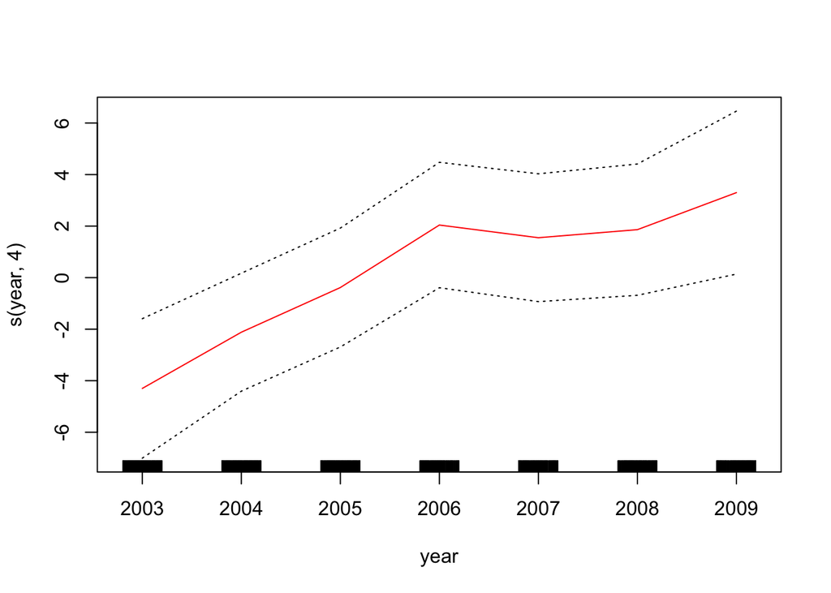

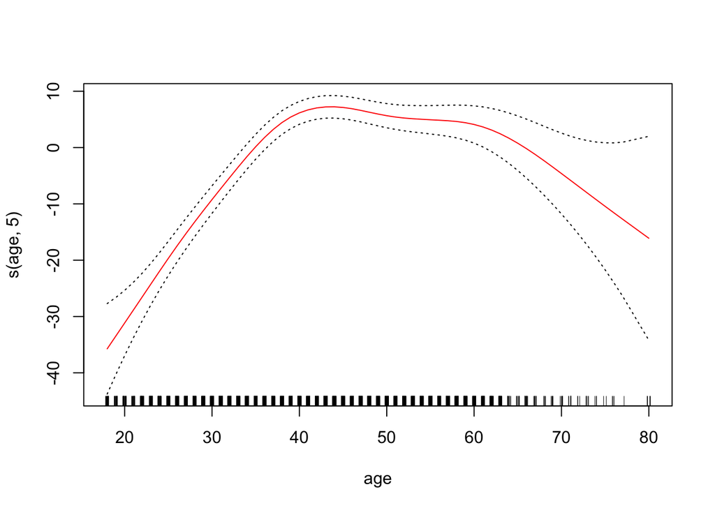

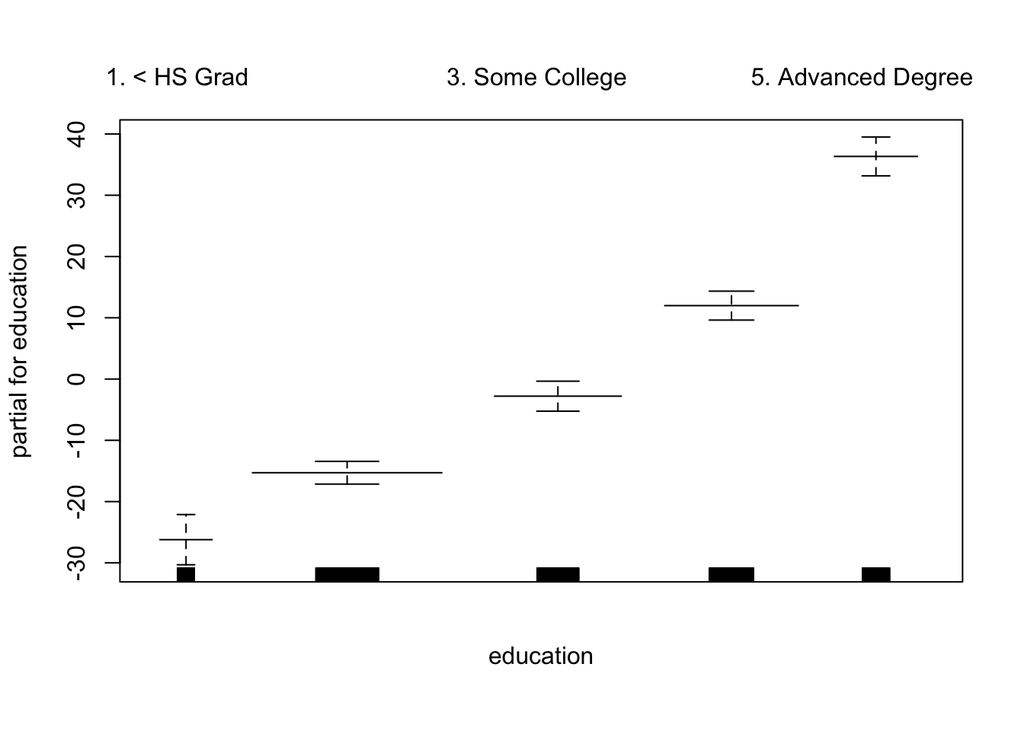

```r
plot(gam_mod, se = TRUE, col = "red")
```

**Python (sklearn)**

```python
from sklearn.preprocessing import OneHotEncoder, SplineTransformer

# Natural cubic spline features of year predictor
ns_tf = make_column_transformer(
  (SplineTransformer(
    n_knots = 4,
    # knots = 'quantile',
    degree = 3,
    extrapolation = 'linear', # natural cubic spline
    # include_bias = False
    ), ['year']),
  (SplineTransformer(
    n_knots = 5,
    # knots = 'quantile',
    degree = 3,
    extrapolation = 'linear', # natural cubic spline
    # include_bias = False
    ), ['age']),
  (OneHotEncoder(drop = 'first'), ['education']),
  remainder = 'drop'
)

# Define pipeline and fit to Wage data
pipe = Pipeline(steps = [
  ("ns_tf", ns_tf),
  ("model", LinearRegression())
])

# Fit pipeline
X = Wage.drop('wage', axis = 1)
y = Wage.wage
pipe.fit(X, y)
```

```
Pipeline(steps=[('ns_tf',
                 ColumnTransformer(transformers=[('splinetransformer-1',
                                                  SplineTransformer(extrapolation='linear',
                                                                    n_knots=4),
                                                  ['year']),
                                                 ('splinetransformer-2',
                                                  SplineTransformer(extrapolation='linear'),
                                                  ['age']),
                                                 ('onehotencoder',
                                                  OneHotEncoder(drop='first'),
                                                  ['education'])])),
                ('model', LinearRegression())])
```

```python
# R^2
pipe.score(X, y)
```

```
0.2924478828190137
```

**Python (statsmodels)**

```python
from statsmodels.gam.api import GLMGam, BSplines

# Create spline basis for year and age
x_spline = Wage[['year', 'age']]
bs = BSplines(x_spline, df = [4, 5], degree = [3, 3])

# Fit GAM
gam_mod = GLMGam.from_formula('wage ~ education', data = Wage, smoother = bs).fit()
gam_mod.summary()
```

Generalized Linear Model Regression Results

| Dep. Variable: | wage | No. Observations: | 3000 |
| --- | --- | --- | --- |
| Model: | GLMGam | Df Residuals: | 2988 |
| Model Family: | Gaussian | Df Model: | 11.00 |
| Link Function: | Identity | Scale: | 1238.8 |
| Method: | PIRLS | Log-Likelihood: | -14934. |
| Date: | Tue, 17 Feb 2026 | Deviance: | 3.7014e+06 |
| Time: | 17:00:56 | Pearson chi2: | 3.70e+06 |
| No. Iterations: | 3 | Pseudo R-squ. (CS): | 0.3358 |
| Covariance Type: | nonrobust |  |  |

|  | coef | std err | z | P>\|z\| | [0.025 | 0.975] |
| --- | --- | --- | --- | --- | --- | --- |
| Intercept | 41.7250 | 5.268 | 7.921 | 0.000 | 31.401 | 52.049 |
| education[T.2. HS Grad] | 10.7413 | 2.431 | 4.418 | 0.000 | 5.977 | 15.506 |
| education[T.3. Some College] | 23.2067 | 2.563 | 9.056 | 0.000 | 18.184 | 28.229 |
| education[T.4. College Grad] | 37.8704 | 2.547 | 14.871 | 0.000 | 32.879 | 42.862 |
| education[T.5. Advanced Degree] | 62.4355 | 2.764 | 22.591 | 0.000 | 57.019 | 67.852 |
| year_s0 | 6.7031 | 4.972 | 1.348 | 0.178 | -3.041 | 16.448 |
| year_s1 | 5.2035 | 4.237 | 1.228 | 0.219 | -3.101 | 13.508 |
| year_s2 | 7.5149 | 2.343 | 3.208 | 0.001 | 2.924 | 12.106 |
| age_s0 | 26.8982 | 7.771 | 3.461 | 0.001 | 11.667 | 42.129 |
| age_s1 | 64.4339 | 5.693 | 11.318 | 0.000 | 53.275 | 75.592 |
| age_s2 | 33.2186 | 9.402 | 3.533 | 0.000 | 14.791 | 51.646 |
| age_s3 | 27.9161 | 11.042 | 2.528 | 0.011 | 6.275 | 49.557 |

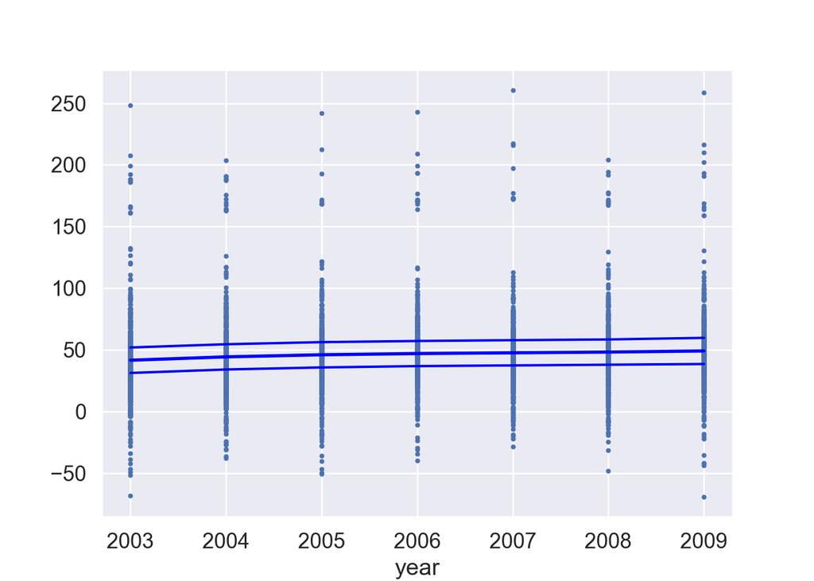

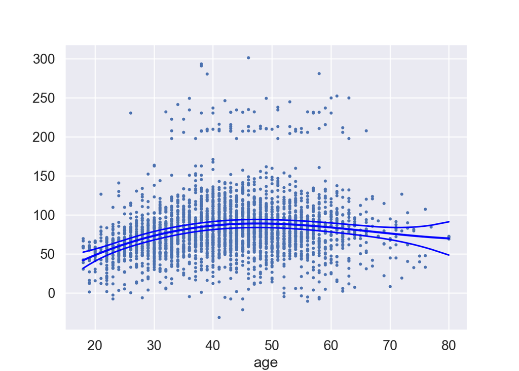

```python
# Plot smooth components
for i in [0, 1]:
  plt.figure()
  gam_mod.plot_partial(i, cpr = True)
  plt.show()
```

## 7 Lab

### 7.1 Polynomial Regression and Step Functions

- To predict wage using a fourth-degree polynomial in age: `poly(age, 4)` in `lm`
- `poly` function creates orthogonal polynomials, which are uncorrelated and have mean zero. Essentially it means that each column is a linear combination of the variables age, age^2, age^3 and age^4.
- Or we can also use `poly()` to obtain age, age^2, age^3 and age^4 directly, if we prefer. We can do this by using the `raw = TRUE` argument to the poly() function.

```r
attach(Wage)
fit <- lm(wage ~ poly(age, 4), data = Wage)
coef(summary(fit))
```

```
                Estimate Std. Error    t value     Pr(>|t|)
(Intercept)    111.70361  0.7287409 153.283015 0.000000e+00
poly(age, 4)1  447.06785 39.9147851  11.200558 1.484604e-28
poly(age, 4)2 -478.31581 39.9147851 -11.983424 2.355831e-32
poly(age, 4)3  125.52169 39.9147851   3.144742 1.678622e-03
poly(age, 4)4  -77.91118 39.9147851  -1.951938 5.103865e-02
```

```r
fit2 <- lm(wage ~ poly(age, 4, raw = T), data = Wage)
coef(summary(fit2))
```

```
                            Estimate   Std. Error   t value     Pr(>|t|)
(Intercept)            -1.841542e+02 6.004038e+01 -3.067172 0.0021802539
poly(age, 4, raw = T)1  2.124552e+01 5.886748e+00  3.609042 0.0003123618
poly(age, 4, raw = T)2 -5.638593e-01 2.061083e-01 -2.735743 0.0062606446
poly(age, 4, raw = T)3  6.810688e-03 3.065931e-03  2.221409 0.0263977518
poly(age, 4, raw = T)4 -3.203830e-05 1.641359e-05 -1.951938 0.0510386498
```

```r
# Equilvalent to
fit3 <- lm(wage ~ age + I(age^2) + I(age^3) + I(age^4), data = Wage)
```

- In performing a polynomial regression we must decide on the degree of the polynomial to use. One way to do this is by using hypothesis tests.

```r
fit.1 <- lm(wage ~ age, data = Wage)
fit.2 <- lm(wage ~ poly(age, 2), data = Wage)
fit.3 <- lm(wage ~ poly(age, 3), data = Wage)
fit.4 <- lm(wage ~ poly(age, 4), data = Wage)
fit.5 <- lm(wage ~ poly(age, 5), data = Wage)
anova(fit.1, fit.2, fit.3, fit.4, fit.5)
```

```
Analysis of Variance Table

Model 1: wage ~ age
Model 2: wage ~ poly(age, 2)
Model 3: wage ~ poly(age, 3)
Model 4: wage ~ poly(age, 4)
Model 5: wage ~ poly(age, 5)
  Res.Df     RSS Df Sum of Sq        F    Pr(>F)
1   2998 5022216
2   2997 4793430  1    228786 143.5931 < 2.2e-16 ***
3   2996 4777674  1     15756   9.8888  0.001679 **
4   2995 4771604  1      6070   3.8098  0.051046 .
5   2994 4770322  1      1283   0.8050  0.369682
---
Signif. codes:  0 '***' 0.001 '**' 0.01 '*' 0.05 '.' 0.1 ' ' 1
```

- As an alternative to using hypothesis tests and ANOVA, we could choose the polynomial degree using cross-validation, as discussed in Chapter 5.
- We can also use step functions to fit a piecewise-constant function. The `cut` function is used to create a qualitative variable that represents the age range. The `lm` function can then be used to fit a step function to the `age` variable.

```r
fit <- glm(I(wage > 250) ~ poly(age, 4), data = Wage, family = binomial)
```

- Once again, we make predictions using the predict() function.

```r
agelims <- range(age)
age.grid <- seq(from = agelims[1], to = agelims[2])
preds <- predict(fit, newdata = list(age = age.grid), se = T)
preds <- predict(fit, newdata = list(age = age.grid), type = "response", se = T)
```

- In order to fit a step function, as discussed in Section 7.2, we use the `cut()` function.

```r
fit <- lm(wage ~ cut(age, 4), data = Wage)
summary(fit)
```

```
Call:
lm(formula = wage ~ cut(age, 4), data = Wage)

Residuals:
    Min      1Q  Median      3Q     Max
-98.126 -24.803  -6.177  16.493 200.519

Coefficients:
                       Estimate Std. Error t value Pr(>|t|)
(Intercept)              94.158      1.476  63.790   <2e-16 ***
cut(age, 4)(33.5,49]     24.053      1.829  13.148   <2e-16 ***
cut(age, 4)(49,64.5]     23.665      2.068  11.443   <2e-16 ***
cut(age, 4)(64.5,80.1]    7.641      4.987   1.532    0.126
---
Signif. codes:  0 '***' 0.001 '**' 0.01 '*' 0.05 '.' 0.1 ' ' 1

Residual standard error: 40.42 on 2996 degrees of freedom
Multiple R-squared:  0.0625,    Adjusted R-squared:  0.06156
F-statistic: 66.58 on 3 and 2996 DF,  p-value: < 2.2e-16
```

### 7.2 Splines

- In order to fit regression splines in R, we use the `splines` library.
- The `bs()` function generates the entire matrix of `bs()` basis functions for splines with the specified set of knots.

```r
library(splines)
fit <- lm(wage ~ bs(age, knots = c(25, 40, 60)), data = Wage)
```

- The `df` option to `bs()` can be used in order to produce a spline with a specified degrees of freedom.

```r
dim(bs(age, knots = c(25, 40, 60)))
```

```
[1] 3000    6
```

```r
dim(bs(age, df = 6))
```

```
[1] 3000    6
```

```r
attr(bs(age, df = 6), "knots")
```

```
[1] 33.75 42.00 51.00
```

- In order to instead fit a natural spline, we use the `ns()` function. Here `ns()` we fit a natural spline with four degrees of freedom.

```r
fit <- lm(wage ~ ns(age, df = 4), data = Wage)
summary(fit)
```

```
Call:
lm(formula = wage ~ ns(age, df = 4), data = Wage)

Residuals:
    Min      1Q  Median      3Q     Max
-98.737 -24.477  -5.083  15.371 204.874

Coefficients:
                 Estimate Std. Error t value Pr(>|t|)
(Intercept)        58.556      4.235  13.827   <2e-16 ***
ns(age, df = 4)1   60.462      4.190  14.430   <2e-16 ***
ns(age, df = 4)2   41.963      4.372   9.597   <2e-16 ***
ns(age, df = 4)3   97.020     10.386   9.341   <2e-16 ***
ns(age, df = 4)4    9.773      8.657   1.129    0.259
---
Signif. codes:  0 '***' 0.001 '**' 0.01 '*' 0.05 '.' 0.1 ' ' 1

Residual standard error: 39.92 on 2995 degrees of freedom
Multiple R-squared:  0.08598,   Adjusted R-squared:  0.08476
F-statistic: 70.43 on 4 and 2995 DF,  p-value: < 2.2e-16
```

- In order to fit a smoothing spline, we use the `smooth.spline()` function.

```r
fit <- smooth.spline(age, wage, df = 16)
fit2 <- smooth.spline(age, wage, cv = TRUE)
```

- local regression

```r
attach(Wage)
plot(age, wage, xlim = agelims, cex = .5, col = "darkgrey") > title("Local Regression")
```

```
logical(0)
```

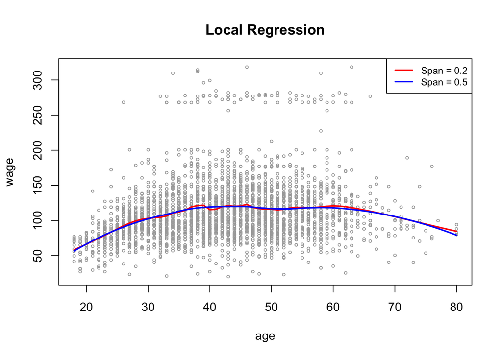

```r
fit <- loess(wage ~ age, span = .2, data = Wage)
fit2 <- loess(wage ~ age, span = .5, data = Wage)
lines(age.grid, predict(fit, data.frame(age = age.grid)), col = "red", lwd = 2)
lines(age.grid, predict(fit2, data.frame(age = age.grid)), col = "blue", lwd = 2)
legend("topright", legend = c("Span = 0.2", "Span = 0.5"), col = c("red", "blue"), lty = 1, lwd = 2, cex = .8)
```

### 7.3 GAMs

- In order to fit a GAM in R, we use the `gam` function, which is part of the `gam` library.
- The `s()` function, which is part of the gam library, is used to indicate that s() we would like to use a smoothing spline.

```r
library(gam)
gam.m3 <- gam(wage ~ s(year, 4) + s(age, 5) + education, data = Wage)
```

```r
gam.m1 <- gam(wage ~ s(age, 5) + education, data = Wage)
gam.m2 <- gam(wage ~ year + s(age, 5) + education, data = Wage)
anova(gam.m1, gam.m2, gam.m3, test = "F")
```

```
Analysis of Deviance Table

Model 1: wage ~ s(age, 5) + education
Model 2: wage ~ year + s(age, 5) + education
Model 3: wage ~ s(year, 4) + s(age, 5) + education
  Resid. Df Resid. Dev Df Deviance       F    Pr(>F)
1      2990    3711731
2      2989    3693842  1  17889.2 14.4771 0.0001447 ***
3      2986    3689770  3   4071.1  1.0982 0.3485661
---
Signif. codes:  0 '***' 0.001 '**' 0.01 '*' 0.05 '.' 0.1 ' ' 1
```

- We can also use local regression fits as building blocks in a GAM, using the `lo()` function.

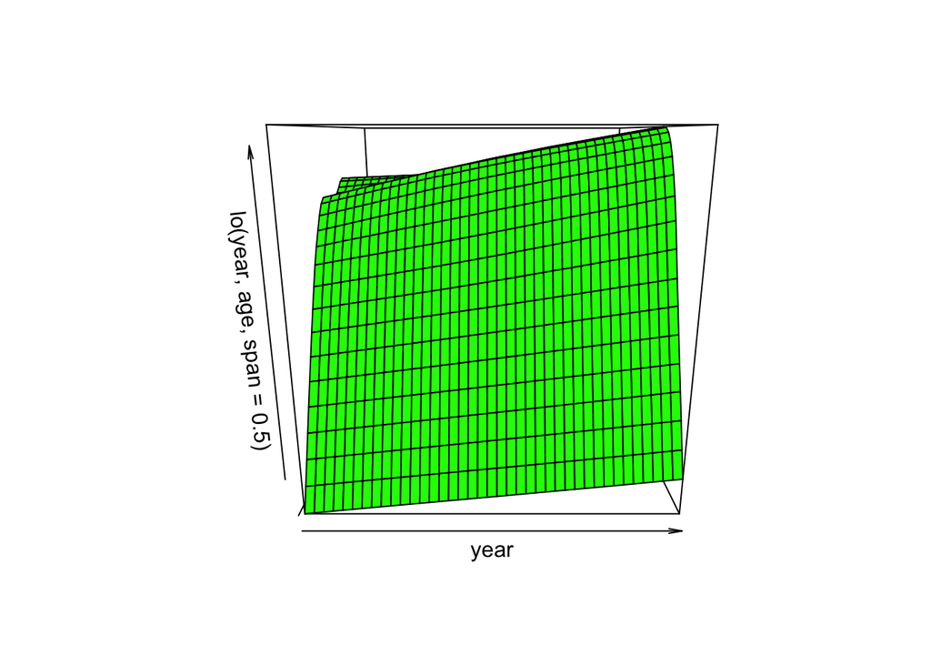

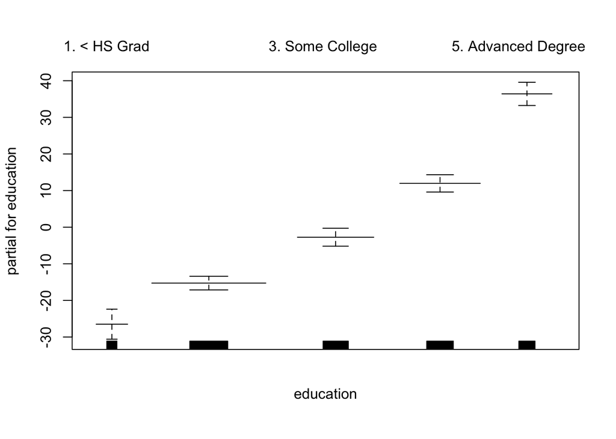

```r
gam.lo <- gam(wage ~ lo(year, age, span = 0.5) + education, data = Wage)
plot(gam.lo, se = TRUE, col = "green")
```